# figtreemap

`figtreemap` lets you add pictures to treemaps.

Treemaps plot a series of rectangles where each rectangle’s size represents a value. They are similar to bar plots but more tightly packed for comparing more categories. `figtreemap` adds pictures to these rectangles making it easier to tell what’s what at a glance. `figtreemap` focuses on adding [phylopics](https://www.phylopic.org/) so is especially good for plotting data about different species.

```python
import matplotlib.pyplot as plt
import figtreemap
```

# Quick start

Here’s a very quick example, using `squarify`’s default random colouring.

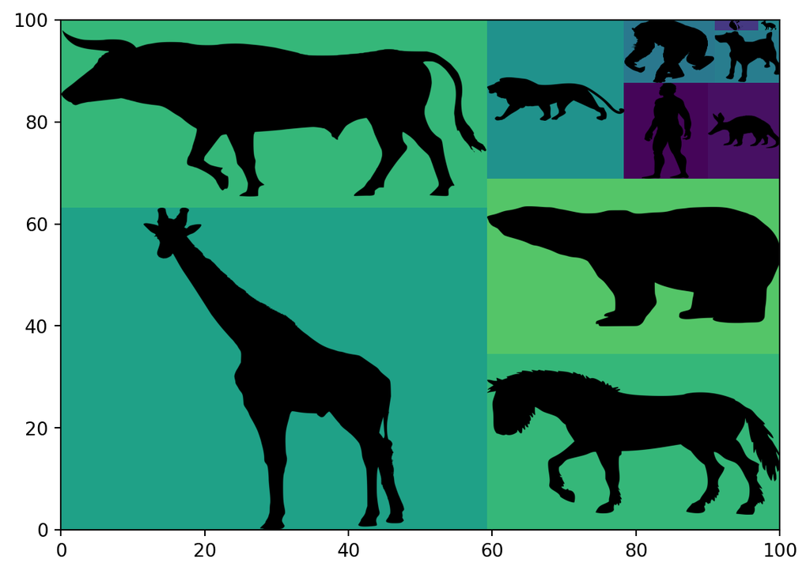

```python
sizes = [30,4,450,700,190,1200,2,50,70,450,60]
names = ["Canis familiaris","Felis catus","Equus ferus","Bos taurus","Panthera leo","Giraffa camelopardalis","Oryctolagus cuniculus","Pan troglodytes","Homo sapiens","Ursus maritimus","Orycteropus afer"]

svgs = [figtreemap.phylopics.get_svg(name) for name in names]
imgs = [figtreemap.image_prep.prep_svg(svg) for svg in svgs]
figtreemap.squarify_images.figtreemap(sizes, imgs)
plt.show()
```

# Step by step

Let’s work through an example using data on mammal sizes.

## Example data

Let’s download some example data on mammal sizes.

```python
import requests
from io import StringIO
import pandas as pd

response = requests.get(
    "https://gist.githubusercontent.com/DAWells/95fcd46057c66aaf33dd9ca7c294c4b2/raw/c670dce7063c6aaf65085eeead5823d9cd497b0f/gestation_mass.csv"
)
mammal_size = pd.read_csv(StringIO(response.text))

sizes = mammal_size.adult_mass_kg
names = mammal_size.latin

mammal_size.head()
```

|  | species | latin | gestation_days | adult_mass_kg | reference for gestation period | reference for the mass | mammal_type |
| --- | --- | --- | --- | --- | --- | --- | --- |
| 0 | African Elephant | Loxodonta africana | 660 | 4800.0 | https://www.msdvetmanual.com/multimedia/table/... | https://thewebsiteofeverything.com/animals/mam... | placental |
| 1 | Dog | Canis familiaris | 62 | 30.0 | https://www.msdvetmanual.com/multimedia/table/... | https://a-z-animals.com/reference/average-weight/ | placental |
| 2 | Cat | Felis catus | 65 | 4.0 | https://www.msdvetmanual.com/multimedia/table/... | https://www.sdhumane.org/resources/animal-size... | placental |
| 3 | Horse | Equus ferus | 335 | 450.0 | https://www.msdvetmanual.com/multimedia/table/... | https://sizegraf.com/blog/list-of-animals-by-s... | placental |
| 4 | Cow | Bos taurus | 280 | 700.0 | https://www.msdvetmanual.com/multimedia/table/... | https://a-z-animals.com/reference/average-weight/ | placental |

## Getting phylopics

Phylopics are an amazing collection of free silhouettes of different species. We can get phylopics just from the latin name. If a phylopic is not available for our species, we take the most specific example available for the lineage.

Name look up is handled by the [opentree](https://opentree.readthedocs.io/en/latest/) package using the [open tree of life](https://tree.opentreeoflife.org/opentree/argus/opentree16.1@ott93302). If you have difficulty getting the correct image, look up the name used in open tree of life.

`figtreemap.phylopics.get_svg()` will download an phylopic SVG based on a given latin name. Here we iterate over a list of names to get a list of SVGs.

```python
svgs = [figtreemap.phylopics.get_svg(name) for name in names]
```

This is one of our SVGs, by default they are black but we’ll colour them based on their value below.

```python
from lxml import etree
from IPython.display import SVG, display
display(SVG(etree.tostring(svgs[0])))
```

[figure not shown]

**Tip**

To avoid downloading the same images a bunch of times, it’s a good idea to save the images so that you can load them locally in future.

```python
# Save SVGs
for name, svg in zip(names, svgs):
    svg.write(
        f"{name}.svg",
        encoding="utf-8",
        xml_declaration=True,
        pretty_print=True,
    )

# Load local SVGs
from lxml import etree

svgs = []
for name in names:
    tree = etree.parse(f"{name}.svg")
    svgs.append(tree)
```

## Preparing images

`figtreemap.image_prep.prep_svg()` converts our SVGs to PNGs ready for plotting but also lets us change attributes of the image like `fill`, and `stroke`. This function uses `*kwargs` to let you set any SVG attributes you like.

```python
hexcolours = figtreemap.image_prep.size_colours(sizes, colormap="plasma")
imgs = [
    figtreemap.image_prep.prep_svg(svg, fill=colour, stroke="black", stroke_width="300")
    for svg, colour in zip(svgs, hexcolours)
]
```

## Making treemaps

`figtreemap.squarify_images.figtreemap()` creates a treemap using [`squarify`](https://github.com/laserson/squarify) and adds our PNGs to the squares. It takes a list of the sizes and a list of the images, which must be in the same order.

We set the colours of our images above in Preparing images, but we can set the colour of the rectangles when creating the plot. `figtreemap.squarify_images.figtreemap()` uses `*kwargs` so any extra arguments are unpacked and passed to `squarify.plot()`.

**Tip**

Setting the rectangles to the same colour as the images but with low alpha is a nice way to make the images stand out.

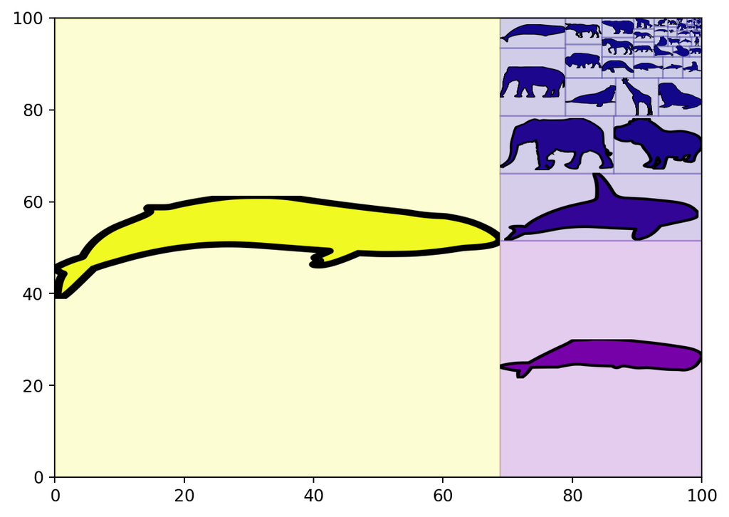

```python
figtreemap.squarify_images.figtreemap(
    sizes,
    imgs,
    facecolor=hexcolours,
    edgecolor=hexcolours,
    alpha=0.2
)
plt.show()
```

# Extra details

## Sorting

By default `figtreemap.squarify_images.figtreemap()` sorts your images so they pack to gether as squarely as possible. If you set `sort=False` you can have more control over the ordering of rectangles but as a result they will be less square.

To illustrate this let’s use the categorical colour map `tab10`. We convert the categories to integers using `.astype("category").cat.codes`, and convert them to colours using `figtreemap.image_prep.size_colours()` as before but we set `normalise` to `False`. Storing these newly coloured images in a dataframe makes it easier to sort sizes and images together.

```python
# Generate categorical colours for mammal_type
categorical_colours = figtreemap.image_prep.size_colours(
    mammal_size.mammal_type.astype("category").cat.codes,
    colormap="tab10",
    normalise=False
)

sorted_data = pd.DataFrame({
    'name': names,
    'size': sizes,
    'mammal_type': mammal_size.mammal_type,
    'svg': svgs,
    'colour': categorical_colours
})

# Convert the SVGs to PNGs with the categorical colour
sorted_data['image'] = [
    figtreemap.image_prep.prep_svg(svg, fill=colour, stroke="black", stroke_width="300")
    for svg, colour in zip(sorted_data.svg, sorted_data.colour)
]

# Sorting the dataframe keeps the correct images and sizes paired up
sorted_data = sorted_data.sort_values(['mammal_type','size'])
```

By default `figtreemap.squarify_images.figtreemap()` ignores the order and sorts everything by the `sizes` argument. This gives the optimal packing.

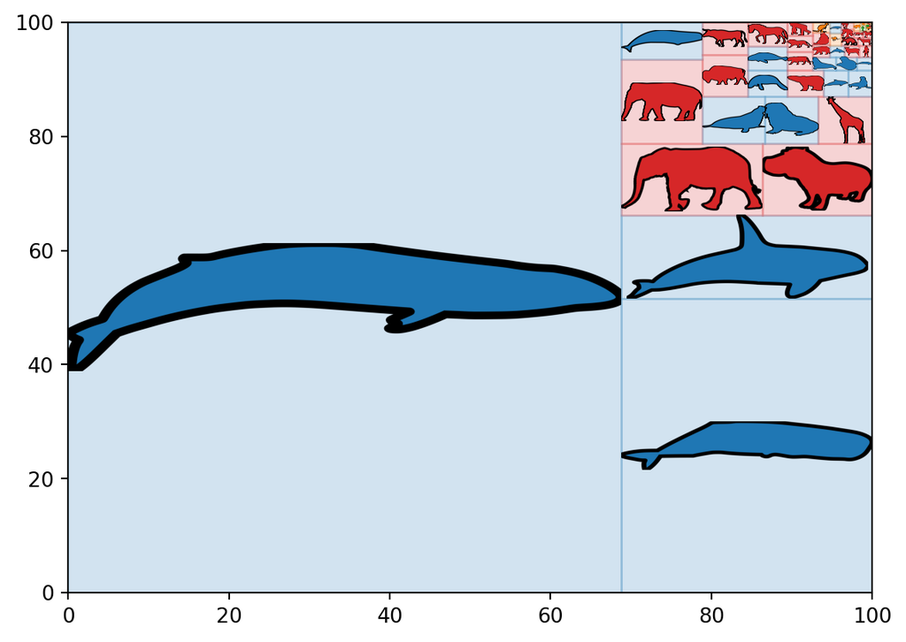

```python
figtreemap.squarify_images.figtreemap(
    sorted_data['size'],
    sorted_data['image'],
    facecolor=sorted_data['colour'],
    alpha=0.2,
    edgecolor=sorted_data['colour'],
)
plt.show()
```

But if you set `sort=False` it uses `sizes` and `images` in the order given. This may lead to less square rectangles but allows you more control on grouping.

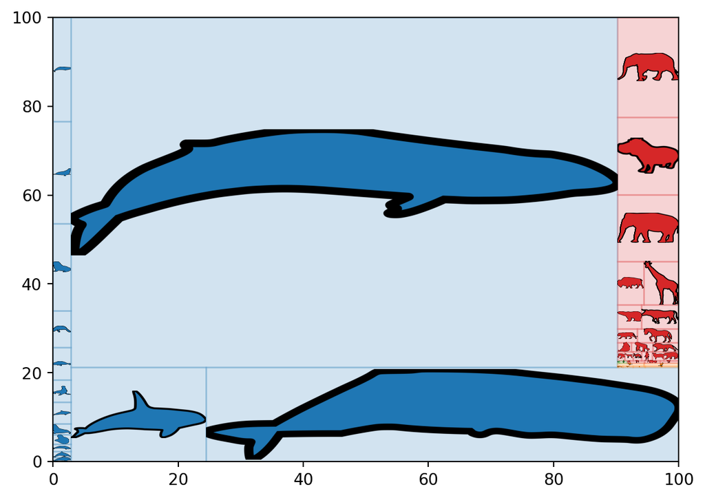

```python
figtreemap.squarify_images.figtreemap(
    sorted_data['size'],
    sorted_data['image'],
    facecolor=sorted_data['colour'],
    alpha=0.2,
    edgecolor=sorted_data['colour'],
    sort=False
)
plt.show()
```

## Letterbox

By default the image is as large as it can be within it’s rectangle without changing the aspect ratio. If you set `letterbox=False`, the image is stretched to fill the rectangle.

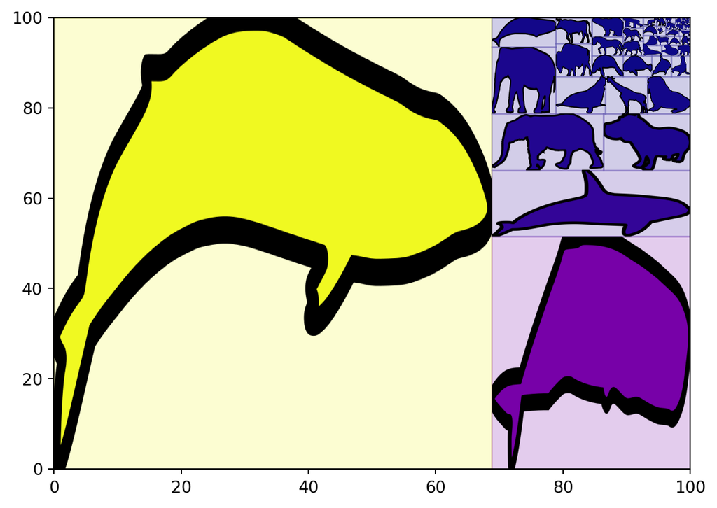

```python
figtreemap.squarify_images.figtreemap(
    sizes,
    imgs,
    facecolor=hexcolours,
    edgecolor=hexcolours,
    alpha=0.2,
    letterbox=False
)
plt.show()
```

# Other pictures

`figtreemap` was build with phylopics in mind, but you can use any other SVG or PNG instead.